# Exploring the relationship between stock prices, macroeconomic variables and gold

# How we worked as a team

We did almost all of the work together with display sharing. Kerstin had a special part and cleaned most of our data for us beforehand. One team member at the time worked on the Notebook while others watched. Everybody provided code snippets, plots, help and solution for the various problems in code we were facing (and there were a lot!). Most of this happened in real time while someone was working on the notebook. We also worked together on both the first and second powerpoint together with “Google Slides”.

We also added a lot of details after our final presentaion based on feedback (as well as more code at the end for predictions).

###Loading all the necessary packages.

```r
if (!require("plyr")) install.packages("plyr")
if (!require("corrplot")) install.packages("corrplot")
if (!require("ggplot2")) install.packages("ggplot2")
if (!require("gridExtra")) install.packages("gridExtra")
if (!require("ggthemes")) install.packages("ggthemes")
if (!require("caret")) install.packages("caret")
if (!require("MASS")) install.packages("MASS")
#if (!require("randomForest")) install.packages("randomForest")
if (!require("rpart")) install.packages("rpart")
if (!require("rpart.plot")) install.packages("rpart.plot")
if (!require("labeling")) install.packages("labeling")
if (!require("dbscan")) install.packages("dbscan")
if(!require("forecast")) install.packages("forecast")
library(plyr)
library(corrplot)
library(ggplot2)
library(gridExtra)
library(ggthemes)
library(caret)
library(MASS)
#library(randomForest)
library(rpart)
library(rpart.plot)
library(labeling)
library(dbscan)
library(forecast)
```

# Data1

As a first step we combined the data we have gathered from various sources to one document and uploaded it to make it arrivable to download for everyone.

```r
data1 <- read.csv(url("https://cdn.discordapp.com/attachments/693802417745166381/700039233603371089/data_set_combined_final.csv"), sep = ";", header = TRUE)
```

Deleting empty rows

```r
data1 <- data1[-c(1,2,60:106),]
```

```r
head(data1)
```

|  | ï..Closing.Price | DJ.Annual | DJ...Change | Annual.Change.DJ | GDP.Per.Capita..US... | Annual.Growth.Rate.... | Annual.Change.Growth.Rate | Inflation.Rate.... | Annual.Change.Inflation | Unemployment.Rate.... | Annual.Change.of.Unemployment |
| --- | --- | --- | --- | --- | --- | --- | --- | --- | --- | --- | --- |
| 3 | 2018 | 23327.46 | -5.63% | -122.45% | 62641.01 | 4.53 | 0.30 | 2.44 | 0.31 | 3.89 | -0.10 |
| 4 | 2017 | 24719.22 | 25.08% | 86.89% | 59927.93 | 3.49 | 0.80 | 2.13 | 0.87 | 4.34 | -0.11 |
| 5 | 2016 | 19762.60 | 13.42% | -701.79% | 57904.20 | 1.94 | -0.40 | 1.26 | 1.14 | 4.88 | -0.08 |
| 6 | 2015 | 17425.03 | -2.23% | -129.65% | 56803.47 | 3.22 | -0.11 | 0.12 | -1.50 | 5.28 | -0.14 |
| 7 | 2014 | 17823.07 | 7.52% | -71.62% | 55032.96 | 3.63 | 0.25 | 1.62 | 0.16 | 6.16 | -0.16 |
| 8 | 2013 | 16576.66 | 26.50% | 265.01% | 53106.91 | 2.91 | -0.16 | 1.46 | -0.60 | 7.36 | -0.09 |

```r
summary(data1)
```

```
 ï..Closing.Price   DJ.Annual        DJ...Change Annual.Change.DJ GDP.Per.Capita..US... Annual.Growth.Rate.... Annual.Change.Growth.Rate
 Min.   :1962     Min.   :  616.2   -0.61% : 1   -116.10%: 1      Min.   : 3244         Min.   :-2.650         Min.   :-4.12000
 1st Qu.:1976     1st Qu.:  905.1   -10.81%: 1   -118.45%: 1      1st Qu.: 8592         1st Qu.: 3.620         1st Qu.:-0.27000
 Median :1990     Median : 2753.2   -15.19%: 1   -119.37%: 1      Median :23889         Median : 4.960         Median : 0.05000
 Mean   :1990     Mean   : 6145.9   -16.58%: 1   -12.96% : 1      Mean   :26204         Mean   : 5.472         Mean   :-0.01246
 3rd Qu.:2004     3rd Qu.:10717.5   -16.76%: 1   -122.45%: 1      3rd Qu.:41713         3rd Qu.: 7.170         3rd Qu.: 0.27000
 Max.   :2018     Max.   :24719.2   -17.27%: 1   -124.46%: 1      Max.   :62641         Max.   :11.770         Max.   : 1.92000
                                    (Other):51   (Other) :51
 Inflation.Rate.... Annual.Change.Inflation Unemployment.Rate.... Annual.Change.of.Unemployment
 Min.   :-0.360     Min.   :-4.20000        Min.   :3.490         Min.   :-0.220000
 1st Qu.: 2.130     1st Qu.:-0.79000        1st Qu.:4.880         1st Qu.:-0.090000
 Median : 3.030     Median : 0.16000        Median :5.640         Median :-0.060000
 Mean   : 3.841     Mean   : 0.02509        Mean   :6.001         Mean   : 0.002456
 3rd Qu.: 4.300     3rd Qu.: 0.99000        3rd Qu.:7.050         3rd Qu.: 0.040000
 Max.   :13.550     Max.   : 4.88000        Max.   :9.710         Max.   : 0.600000
```

Because the variable “DJ Change” still contains the percentage sign the data type is not numeric. Therefore we simply remove the “%” to make the variable usable.

```r
data1$DJ...Change = as.numeric(gsub("[\\%,]", "", data1$DJ...Change))


data1$Annual.Change.DJ = as.numeric(gsub("[\\%,]", "", data1$Annual.Change.DJ))
data1$Annual.Change.DJ <- as.numeric(as.character(data1$Annual.Change.DJ)) / 100
```

Also, we rename the colums to get rid of the dots and make easier to understand.

```r
colnames(data1) <- c("Year", "DJ Annual", "DJ Change","Annual Change DJ", "GDP per Capita US", "Annual Growth Rate", "Annual Change Growth Rate", "Inflation Rate", "Annual Change Inflation", "Unemployment Rate", "Annual Change of Unemployment")
```

```r
head(data1)
```

|  | Year | DJ Annual | DJ Change | Annual Change DJ | GDP per Capita US | Annual Growth Rate | Annual Change Growth Rate | Inflation Rate | Annual Change Inflation | Unemployment Rate | Annual Change of Unemployment |
| --- | --- | --- | --- | --- | --- | --- | --- | --- | --- | --- | --- |
| 3 | 2018 | 23327.46 | -5.63 | -1.2245 | 62641.01 | 4.53 | 0.30 | 2.44 | 0.31 | 3.89 | -0.10 |
| 4 | 2017 | 24719.22 | 25.08 | 0.8689 | 59927.93 | 3.49 | 0.80 | 2.13 | 0.87 | 4.34 | -0.11 |
| 5 | 2016 | 19762.60 | 13.42 | -7.0179 | 57904.20 | 1.94 | -0.40 | 1.26 | 1.14 | 4.88 | -0.08 |
| 6 | 2015 | 17425.03 | -2.23 | -1.2965 | 56803.47 | 3.22 | -0.11 | 0.12 | -1.50 | 5.28 | -0.14 |
| 7 | 2014 | 17823.07 | 7.52 | -0.7162 | 55032.96 | 3.63 | 0.25 | 1.62 | 0.16 | 6.16 | -0.16 |
| 8 | 2013 | 16576.66 | 26.50 | 2.6501 | 53106.91 | 2.91 | -0.16 | 1.46 | -0.60 | 7.36 | -0.09 |

```r
summary(data1)
```

```
      Year        DJ Annual         DJ Change       Annual Change DJ   GDP per Capita US Annual Growth Rate Annual Change Growth Rate Inflation Rate
 Min.   :1962   Min.   :  616.2   Min.   :-33.840   Min.   :-27.7049   Min.   : 3244     Min.   :-2.650     Min.   :-4.12000          Min.   :-0.360
 1st Qu.:1976   1st Qu.:  905.1   1st Qu.: -3.150   1st Qu.: -1.8025   1st Qu.: 8592     1st Qu.: 3.620     1st Qu.:-0.27000          1st Qu.: 2.130
 Median :1990   Median : 2753.2   Median :  7.520   Median : -0.8176   Median :23889     Median : 4.960     Median : 0.05000          Median : 3.030
 Mean   :1990   Mean   : 6145.9   Mean   :  7.454   Mean   : -1.2324   Mean   :26204     Mean   : 5.472     Mean   :-0.01246          Mean   : 3.841
 3rd Qu.:2004   3rd Qu.:10717.5   3rd Qu.: 18.820   3rd Qu.:  0.0342   3rd Qu.:41713     3rd Qu.: 7.170     3rd Qu.: 0.27000          3rd Qu.: 4.300
 Max.   :2018   Max.   :24719.2   Max.   : 38.320   Max.   : 14.6308   Max.   :62641     Max.   :11.770     Max.   : 1.92000          Max.   :13.550
 Annual Change Inflation Unemployment Rate Annual Change of Unemployment
 Min.   :-4.20000        Min.   :3.490     Min.   :-0.220000
 1st Qu.:-0.79000        1st Qu.:4.880     1st Qu.:-0.090000
 Median : 0.16000        Median :5.640     Median :-0.060000
 Mean   : 0.02509        Mean   :6.001     Mean   : 0.002456
 3rd Qu.: 0.99000        3rd Qu.:7.050     3rd Qu.: 0.040000
 Max.   : 4.88000        Max.   :9.710     Max.   : 0.600000
```

```r
str(data1)
```

```
'data.frame':   57 obs. of  11 variables:
 $ Year                         : int  2018 2017 2016 2015 2014 2013 2012 2011 2010 2009 ...
 $ DJ Annual                    : num  23327 24719 19763 17425 17823 ...
 $ DJ Change                    : num  -5.63 25.08 13.42 -2.23 7.52 ...
 $ Annual Change DJ             : num  -1.224 0.869 -7.018 -1.296 -0.716 ...
 $ GDP per Capita US            : num  62641 59928 57904 56803 55033 ...
 $ Annual Growth Rate           : num  4.53 3.49 1.94 3.22 3.63 2.91 3.45 2.92 2.9 -2.65 ...
 $ Annual Change Growth Rate    : num  0.3 0.8 -0.4 -0.11 0.25 -0.16 0.18 0.01 -2.09 -4.12 ...
 $ Inflation Rate               : num  2.44 2.13 1.26 0.12 1.62 1.46 2.07 3.16 1.64 -0.36 ...
 $ Annual Change Inflation      : num  0.31 0.87 1.14 -1.5 0.16 -0.6 -1.09 1.52 2 -4.19 ...
 $ Unemployment Rate            : num  3.89 4.34 4.88 5.28 6.16 7.36 8.08 8.93 9.61 9.28 ...
 $ Annual Change of Unemployment: num  -0.1 -0.11 -0.08 -0.14 -0.16 -0.09 -0.1 -0.07 0.04 0.6 ...
```

Year … Year DJ Annual … Value of the Dow Jones index on 31.12.XX [$] DJ Change … Change of Dow Jones in comparision to the year before Annual Change DJ … Change of the dow jones change GDP per Capital US … gross domestic product of the USA [$] Annual Growth Rate … Change of the GDP per year Annual Change Growth Rate … Change of the gdp per year change Inflation Rate … The rate of the inflation [] Annual Change Inflation … Change of the inflation per year Unemployment Rate … The percentage of unemployed people in the USA Annual Change of Unemployment … Change of the unemployment rate per year

Create categorical variables for analysis

```r
data1$`DJ_Change_factor` <- factor(with(data1, ifelse((data1$`DJ Change` > 0), 1, 0)),labels = c("neg", "pos"))
`Annual_DJ_Change_factor` <- with(data1, ifelse((data1$`Annual Change DJ` > 0), 1, 0))
`Annual_Change_Growth_Rate_factor` <- with(data1, ifelse((data1$`Annual Change Growth Rate` > 0), 1, 0))
`Annual_Change_Inflation_factor` <- with(data1, ifelse((data1$`Annual Change Inflation` > 0), 1, 0))
`Annual_Change_of_Unemployment_factor` <- with(data1, ifelse((data1$`Annual Change of Unemployment` > 0), 1, 0))
```

```r
str(data1)
```

```
'data.frame':   57 obs. of  12 variables:
 $ Year                         : int  2018 2017 2016 2015 2014 2013 2012 2011 2010 2009 ...
 $ DJ Annual                    : num  23327 24719 19763 17425 17823 ...
 $ DJ Change                    : num  -5.63 25.08 13.42 -2.23 7.52 ...
 $ Annual Change DJ             : num  -1.224 0.869 -7.018 -1.296 -0.716 ...
 $ GDP per Capita US            : num  62641 59928 57904 56803 55033 ...
 $ Annual Growth Rate           : num  4.53 3.49 1.94 3.22 3.63 2.91 3.45 2.92 2.9 -2.65 ...
 $ Annual Change Growth Rate    : num  0.3 0.8 -0.4 -0.11 0.25 -0.16 0.18 0.01 -2.09 -4.12 ...
 $ Inflation Rate               : num  2.44 2.13 1.26 0.12 1.62 1.46 2.07 3.16 1.64 -0.36 ...
 $ Annual Change Inflation      : num  0.31 0.87 1.14 -1.5 0.16 -0.6 -1.09 1.52 2 -4.19 ...
 $ Unemployment Rate            : num  3.89 4.34 4.88 5.28 6.16 7.36 8.08 8.93 9.61 9.28 ...
 $ Annual Change of Unemployment: num  -0.1 -0.11 -0.08 -0.14 -0.16 -0.09 -0.1 -0.07 0.04 0.6 ...
 $ DJ_Change_factor             : Factor w/ 2 levels "neg","pos": 1 2 2 1 2 2 2 2 2 2 ...
```

```r
m <- cor(data1[, c(2,5,8,10)])
m
```

```
                   DJ Annual GDP per Capita US Inflation Rate Unemployment Rate
DJ Annual          1.0000000        0.94133649     -0.4880985       -0.14258977
GDP per Capita US  0.9413365        1.00000000     -0.4732399        0.03563392
Inflation Rate    -0.4880985       -0.47323992      1.0000000        0.14481701
Unemployment Rate -0.1425898        0.03563392      0.1448170        1.00000000
```

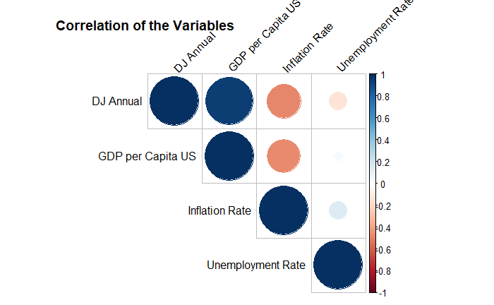

```r
corrplot(m, type="upper", order="hclust", tl.col="black", tl.srt=45)
title("Correlation of the Variables", adj = 0.001, line = -0.1)
```

## Correlation of Changes

```r
cor(data1[, c(4,7,9,11)])
```

```
                              Annual Change DJ Annual Change Growth Rate Annual Change Inflation Annual Change of Unemployment
Annual Change DJ                    1.00000000                0.08329915              0.02782644                   -0.03940279
Annual Change Growth Rate           0.08329915                1.00000000              0.12069032                   -0.52820654
Annual Change Inflation             0.02782644                0.12069032              1.00000000                   -0.32305966
Annual Change of Unemployment      -0.03940279               -0.52820654             -0.32305966                    1.00000000
```

## Simple linear regression

### Fitting the model

We fitted a simple linear regression `DJ Annual ~GDP per Capita US` using OLS using the `lm()` function:

```r
fitGrowth <- lm(`DJ Annual` ~ `GDP per Capita US`, data = data1)
```

The fitted coefficients are:

```r
fitGrowth
```

```
Call:
lm(formula = `DJ Annual` ~ `GDP per Capita US`, data = data1)

Coefficients:
        (Intercept)  `GDP per Capita US`
         -2512.6577               0.3304
```

We plotted the fitted regression line:

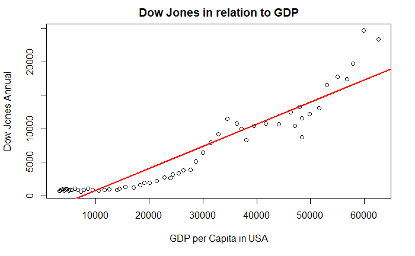

```r
plot(`DJ Annual` ~`GDP per Capita US`, data = data1,
     ylab = "Dow Jones Annual", xlab = "GDP per Capita in USA",
     main = "Dow Jones in relation to GDP")
abline(fitGrowth, col = "red", lwd = 2)
```

we can see the positive correlation between the Dow Jones index and the GDP per capita.

Using the Dow Jones Change per year as the dependent variable and the Annual gdp growth rate as independent variable for the regression line. model: `DJ Changes ~ Change Growth Rate`

```r
fitGr <- lm(data1$`DJ Change` ~ data1$`Annual Growth Rate`, data = data1)
```

The fitted coefficients are:

```r
fitGr
```

```
Call:
lm(formula = data1$`DJ Change` ~ data1$`Annual Growth Rate`,
    data = data1)

Coefficients:
               (Intercept)  data1$`Annual Growth Rate`
                    13.340                      -1.076
```

We can plot the fitted regression line:

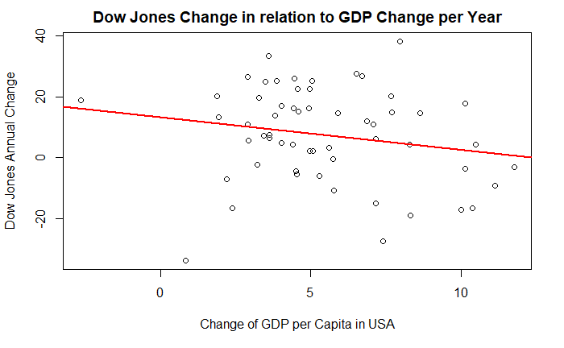

```r
plot(data1$`DJ Change` ~ data1$`Annual Growth Rate`, data = data1,
     ylab = "Dow Jones Annual Change", xlab = "Change of GDP per Capita in USA",
     main = "Dow Jones Change in relation to GDP Change per Year")
abline(fitGr, col = "red", lwd = 2)
```

We obtain a slight negative correlation between the dow jones changes per year and the gdp change per year. This is suprisingly, whereas the dow jones and the gdp per capita are positively correlated the changes of dow jones and gdp are lightly negative correlated.

We repeated the same for the other independent variables inflation rate and unemployment rate per year:

```r
fitInf <- lm(`DJ Change` ~ `Inflation Rate`, data = data1)
```

```r
fitInf
```

```
Call:
lm(formula = `DJ Change` ~ `Inflation Rate`, data = data1)

Coefficients:
     (Intercept)  `Inflation Rate`
          11.761            -1.122
```

We can plot the fitted regression line:

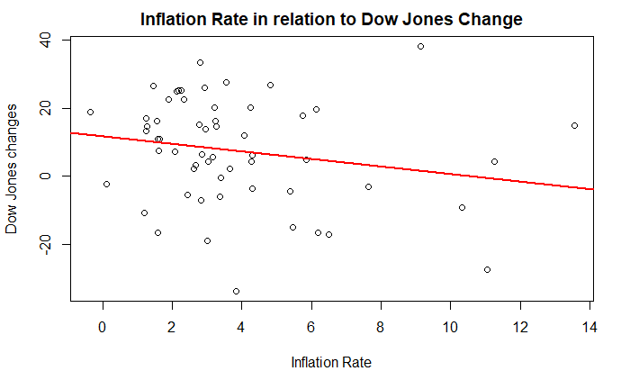

```r
plot(`DJ Change` ~ `Inflation Rate`, data = data1,
     ylab = "Dow Jones changes", xlab = "Inflation Rate", main = "Inflation Rate in relation to Dow Jones Change")
abline(fitInf, col = "red", lwd = 2)
```

Unemployment rate:

```r
fitUn <- lm(data1$`DJ Change` ~ data1$`Unemployment Rate`, data = data1)
```

```r
fitUn
```

```
Call:
lm(formula = data1$`DJ Change` ~ data1$`Unemployment Rate`, data = data1)

Coefficients:
              (Intercept)  data1$`Unemployment Rate`
                   -6.993                      2.407
```

We can plot the fitted regression line:

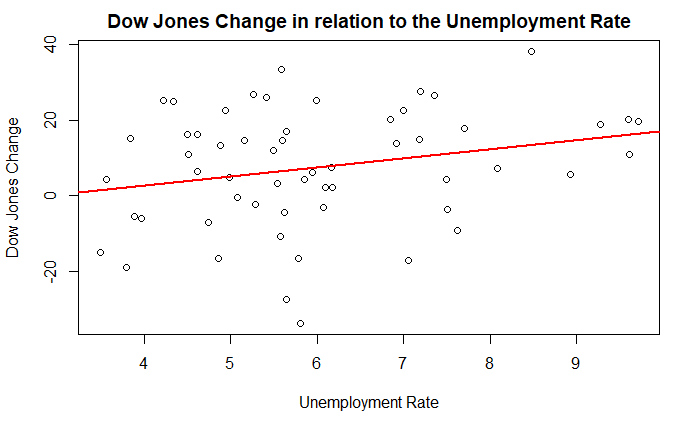

```r
plot(`DJ Change` ~ `Unemployment Rate`, data = data1,
     ylab = "Dow Jones Change", xlab = "Unemployment Rate",main = "Dow Jones Change in relation to the Unemployment Rate")
abline(fitUn, col = "red", lwd = 2)
```

Can we visualize positice Dow Jones changes when annual growth rate is high and unemployment rate is low? Are their negative Dow Jones changes when annual growth rate is low and the unemployment rate is high?

[figure not shown]

```r
plot(`Annual Growth Rate` ~ `Unemployment Rate`,
     ylab = "Annual Growth Rate", xlab = "Unemployment Rate", main = "Annual Growth Rate ~ Unemployment with Dow Jones Changes in Color",
     col = Annual_DJ_Change_factor+1,
     data = data1)
legend("bottomright", title = "DJ Change", pch = 1,
       col = c(1, 2),
       legend= c("Positive", "Negative"))
```

We don’t get the result we expected. Instead, we can’t dedect a clear relationsship between the variables.

So lets look at the inflation rate:

[figure not shown]

```r
plot(data1$`Annual Growth Rate` ~ data1$`Inflation Rate`,
     ylab = "Annual Growth Rate", xlab = "Inflation Rate", main = "Annual Growth ~ Inflation with Dow Jones Changes in Color",
     col = Annual_DJ_Change_factor+1,
     data = data1)
legend("bottomright", title = "DJ Changes", pch = 1,
       col = c(1, 2),
       legend= c("Positive", "Negative"))
```

The same with Annual Growth Rate and Inflation Rate, we can’t recognize a clear relationship for negative and positve dow jones changes.

## Multiple Linear regression

```r
fitGrInUn <- lm(`DJ Change` ~ `Annual Growth Rate` + `Inflation Rate` + `Unemployment Rate`, data = data1)
```

The fitted coefficients are:

```r
fitGrInUn
```

```
Call:
lm(formula = `DJ Change` ~ `Annual Growth Rate` + `Inflation Rate` +
    `Unemployment Rate`, data = data1)

Coefficients:
         (Intercept)  `Annual Growth Rate`      `Inflation Rate`   `Unemployment Rate`
             -2.9477               -0.1885               -1.2266                2.6902
```

```r
## forward-backward selection based on AIC
fitStep <- step(fitGrInUn, direction = "both")
```

```
Start:  AIC=312.71
`DJ Change` ~ `Annual Growth Rate` + `Inflation Rate` + `Unemployment Rate`

                       Df Sum of Sq   RSS    AIC
- `Annual Growth Rate`  1      9.18 11963 310.75
- `Inflation Rate`      1    379.42 12333 312.49
<none>                              11954 312.71
- `Unemployment Rate`   1    964.52 12918 315.13

Step:  AIC=310.75
`DJ Change` ~ `Inflation Rate` + `Unemployment Rate`

                       Df Sum of Sq   RSS    AIC
<none>                              11963 310.75
- `Inflation Rate`      1    781.51 12745 312.36
+ `Annual Growth Rate`  1      9.18 11954 312.71
- `Unemployment Rate`   1   1060.75 13024 313.60
```

```r
fitStep
```

```
Call:
lm(formula = `DJ Change` ~ `Inflation Rate` + `Unemployment Rate`,
    data = data1)

Coefficients:
        (Intercept)     `Inflation Rate`  `Unemployment Rate`
             -3.862               -1.349                2.749
```

### Goodness of fit

#### $R^2$ statistic

The $R^2$ statistic can be extracted by:

```r
summary(fitGr)$r.squared
```

```
[1] 0.03773997
```

```r
summary(fitUn)$r.squared
```

```
[1] 0.06120301
```

```r
summary(fitInf)$r.squared
```

```
[1] 0.04063306
```

####AIC

```r
AIC(fitGrInUn, fitStep)
```

|  | df | AIC |
| --- | --- | --- |
| fitGrInUn | 5 | 476.4676 |
| fitStep | 4 | 474.5114 |

The model with two independent variables fits best. According to the adjusted $R^2$ we have the same decision:

```r
c(summary(fitGrInUn)$adj.r.squared, summary(fitStep)$adj.r.squared)
```

```
[1] 0.06960396 0.08613240
```

### Predictions and out of sample performance

Create new data where the inflation rate increase by 1.3% and the Unemployment rate is 5.5%

```r
new_d <- data.frame(`DJ Change` = NA, `Inflation Rate` = 1.30, `Unemployment Rate` = 5.50)
colnames(new_d) <- c("DJ Change", "Inflation Rate", "Unemployment Rate")
new_d
```

| DJ Change | Inflation Rate | Unemployment Rate |
| --- | --- | --- |
| NA | 1.3 | 5.5 |

#### Prediction accuracy

One can compute a confidence interval in order to determine how close the predictions will be to the true regression line.

```r
predict(fitStep, newdata = new_d, interval = "confidence", level = 0.95)
```

```
       fit     lwr      upr
1 9.504234 4.09464 14.91383
```

```r
predict(fitStep, newdata = new_d, interval = "prediction", level = 0.95)
```

```
       fit       lwr      upr
1 9.504234 -20.82315 39.83162
```

#### Out-of-sample performance

For assessing the predictive power of the model, one typically sets up an out of sample exercise in the following way. The data set is split into a training and a test sample:

- the model will be estimated on the training sample
- its performance will be evaluated on the test sample.

```r
## keep last 10% of the observations for testing

train_dat <- data1[1:floor(58*0.8), ]
test_dat  <- data1[-(1:floor(58*0.8)), ]
```

Fit the three models on the training set:

```r
fitInUn <- lm(`DJ Change` ~ `Inflation Rate`+ `Unemployment Rate`, data = train_dat)
fitall <- lm(`DJ Change` ~ `Annual Growth Rate`+`Inflation Rate`+ `Unemployment Rate`,
             data = train_dat)
```

In `R` we can compute the predictions of the models for the test set in the following way:

```r
## compute the prediction errors
y_hat_InUn <- predict(fitInUn, newdata = test_dat) # predictions

y_hat_all <- predict(fitall, newdata = test_dat) # predictions
```

The root mean squared errors are the given by:

```r
## root mean squared error
sqrt(c(mean((y_hat_InUn - test_dat$`DJ Change`)^2),
       mean((y_hat_all - test_dat$`DJ Change`)^2)))
```

```
[1] 11.45817 11.51399
```

The lowest mean squared error is achieved by the first model. In this case the in sample and out of sample performance favors same model.

As a conclusion we can say the the model `DJ Change` ~ `Inflation Rate`+ `Unemployment Rate` fits the best in our linear regression.

But is that really the best model we could find? Let’s see what result we will get from a multiple logistic regression using the dow jones change as a categorical variable :

## Multiple Logistic Regression

```r
## Estimating multiple logistic regression
## using all variables

fit_logit <- glm(DJ_Change_factor ~ `Annual Growth Rate`+
                   `Unemployment Rate`+ `Inflation Rate`,
           data = data1, family = binomial())
summary(fit_logit)
```

```
Call:
glm(formula = DJ_Change_factor ~ `Annual Growth Rate` + `Unemployment Rate` +
    `Inflation Rate`, family = binomial(), data = data1)

Deviance Residuals:
    Min       1Q   Median       3Q      Max
-1.9233  -1.0128   0.5863   0.8742   1.4645

Coefficients:
                     Estimate Std. Error z value Pr(>|z|)
(Intercept)           -0.6536     1.4843  -0.440   0.6597
`Annual Growth Rate`  -0.1552     0.1517  -1.023   0.3063
`Unemployment Rate`    0.4995     0.2554   1.956   0.0505 .
`Inflation Rate`      -0.1149     0.1405  -0.818   0.4136
---
Signif. codes:  0 ‘***’ 0.001 ‘**’ 0.01 ‘*’ 0.05 ‘.’ 0.1 ‘ ’ 1

(Dispersion parameter for binomial family taken to be 1)

    Null deviance: 69.468  on 56  degrees of freedom
Residual deviance: 61.202  on 53  degrees of freedom
AIC: 69.202

Number of Fisher Scoring iterations: 5
```

```r
summary(data1)
```

```
      Year        DJ Annual         DJ Change       Annual Change DJ   GDP per Capita US Annual Growth Rate Annual Change Growth Rate Inflation Rate
 Min.   :1962   Min.   :  616.2   Min.   :-33.840   Min.   :-27.7049   Min.   : 3244     Min.   :-2.650     Min.   :-4.12000          Min.   :-0.360
 1st Qu.:1976   1st Qu.:  905.1   1st Qu.: -3.150   1st Qu.: -1.8025   1st Qu.: 8592     1st Qu.: 3.620     1st Qu.:-0.27000          1st Qu.: 2.130
 Median :1990   Median : 2753.2   Median :  7.520   Median : -0.8176   Median :23889     Median : 4.960     Median : 0.05000          Median : 3.030
 Mean   :1990   Mean   : 6145.9   Mean   :  7.454   Mean   : -1.2324   Mean   :26204     Mean   : 5.472     Mean   :-0.01246          Mean   : 3.841
 3rd Qu.:2004   3rd Qu.:10717.5   3rd Qu.: 18.820   3rd Qu.:  0.0342   3rd Qu.:41713     3rd Qu.: 7.170     3rd Qu.: 0.27000          3rd Qu.: 4.300
 Max.   :2018   Max.   :24719.2   Max.   : 38.320   Max.   : 14.6308   Max.   :62641     Max.   :11.770     Max.   : 1.92000          Max.   :13.550
 Annual Change Inflation Unemployment Rate Annual Change of Unemployment DJ_Change_factor
 Min.   :-4.20000        Min.   :3.490     Min.   :-0.220000             neg:17
 1st Qu.:-0.79000        1st Qu.:4.880     1st Qu.:-0.090000             pos:40
 Median : 0.16000        Median :5.640     Median :-0.060000
 Mean   : 0.02509        Mean   :6.001     Mean   : 0.002456
 3rd Qu.: 0.99000        3rd Qu.:7.050     3rd Qu.: 0.040000
 Max.   : 4.88000        Max.   :9.710     Max.   : 0.600000
```

### Model selection

```r
data1_NAomit <- na.omit(data1)

fit_logit_all <- glm(DJ_Change_factor ~ .,
                     data = data1_NAomit[, -c(1,2,3,4)], #Excluding the Dow Jones variables
                     family = binomial())
fit_logit_step <- step(fit_logit_all)
```

```
Start:  AIC=73.75
DJ_Change_factor ~ `GDP per Capita US` + `Annual Growth Rate` +
    `Annual Change Growth Rate` + `Inflation Rate` + `Annual Change Inflation` +
    `Unemployment Rate` + `Annual Change of Unemployment`

                                  Df Deviance    AIC
- `Annual Change Growth Rate`      1   57.786 71.786
- `Inflation Rate`                 1   58.065 72.065
- `Annual Change Inflation`        1   58.439 72.439
- `Annual Change of Unemployment`  1   59.184 73.184
<none>                                 57.746 73.746
- `GDP per Capita US`              1   60.963 74.963
- `Unemployment Rate`              1   61.054 75.054
- `Annual Growth Rate`             1   61.378 75.378

Step:  AIC=71.79
DJ_Change_factor ~ `GDP per Capita US` + `Annual Growth Rate` +
    `Inflation Rate` + `Annual Change Inflation` + `Unemployment Rate` +
    `Annual Change of Unemployment`

                                  Df Deviance    AIC
- `Inflation Rate`                 1   58.080 70.080
- `Annual Change Inflation`        1   58.531 70.531
- `Annual Change of Unemployment`  1   59.247 71.247
<none>                                 57.786 71.786
- `GDP per Capita US`              1   60.978 72.978
- `Unemployment Rate`              1   61.115 73.115
- `Annual Growth Rate`             1   61.480 73.480

Step:  AIC=70.08
DJ_Change_factor ~ `GDP per Capita US` + `Annual Growth Rate` +
    `Annual Change Inflation` + `Unemployment Rate` + `Annual Change of Unemployment`

                                  Df Deviance    AIC
- `Annual Change Inflation`        1   58.531 68.531
- `Annual Change of Unemployment`  1   59.681 69.681
<none>                                 58.080 70.080
- `GDP per Capita US`              1   61.000 71.000
- `Unemployment Rate`              1   62.020 72.020
- `Annual Growth Rate`             1   64.079 74.079
```

[output cut: 14 more lines]

```
    `Unemployment Rate`

                       Df Deviance    AIC
- `GDP per Capita US`   1   61.869 67.869
<none>                      60.182 68.182
- `Unemployment Rate`   1   64.433 70.433
- `Annual Growth Rate`  1   65.557 71.557

Step:  AIC=67.87
DJ_Change_factor ~ `Annual Growth Rate` + `Unemployment Rate`

                       Df Deviance    AIC
<none>                      61.869 67.869
- `Annual Growth Rate`  1   65.641 69.641
- `Unemployment Rate`   1   65.966 69.966
```

Print the summary of the chosen model:

```r
summary(fit_logit_step)
```

```
Call:
glm(formula = DJ_Change_factor ~ `Annual Growth Rate` + `Unemployment Rate`,
    family = binomial(), data = data1_NAomit[, -c(1, 2, 3, 4)])

Deviance Residuals:
    Min       1Q   Median       3Q      Max
-2.0660  -0.9876   0.6158   0.8780   1.4819

Coefficients:
                     Estimate Std. Error z value Pr(>|z|)
(Intercept)           -0.3731     1.4247  -0.262   0.7934
`Annual Growth Rate`  -0.2292     0.1225  -1.871   0.0613 .
`Unemployment Rate`    0.4442     0.2401   1.850   0.0643 .
---
Signif. codes:  0 ‘***’ 0.001 ‘**’ 0.01 ‘*’ 0.05 ‘.’ 0.1 ‘ ’ 1

(Dispersion parameter for binomial family taken to be 1)

    Null deviance: 69.468  on 56  degrees of freedom
Residual deviance: 61.869  on 54  degrees of freedom
AIC: 67.869

Number of Fisher Scoring iterations: 4
```

In contrast to the linear regression the logistic regression delivers the model `DJ_Change_factor ~ Annual Growth Rate + Unemployment Rate` as the best.

## Predictions with the newly chosen model

Lets assign new values to the independent variables and check the performance on prediction

```r
x_new <- data.frame(DJ_Change_factor = c(1, 0),
                    `Annual Growth Rate` = c(4.00, 1.00),
                    `Unemployment Rate` = c(3.00, 7.00))

colnames(x_new) <- c("DJ_Change_factor", "Annual Growth Rate", "Unemployment Rate")

x_new
```

| DJ_Change_factor | Annual Growth Rate | Unemployment Rate |
| --- | --- | --- |
| 1 | 4 | 3 |
| 0 | 1 | 7 |

What would be the predicted probability of positive DJ Change? Using the `predict()` function.

For getting the probability of default we need the argument type `type = "response"`:

```r
predict(fit_logit_step, newdata = x_new, type = "response")
```

```
        1         2
0.5106164 0.9246240
```

The best model we get from the logistic regression is `DJ_Change_factor ~ Annual Growth Rate + Unemployment Rate` Now we have obtain two different model, but don’t know whats really the best model. So let’s take another try and use the classification tree.

## Classification trees

Let’s built a classification tree to find a appropriate classification.

```r
str(data1)
```

```
'data.frame':   57 obs. of  12 variables:
 $ Year                         : int  2018 2017 2016 2015 2014 2013 2012 2011 2010 2009 ...
 $ DJ Annual                    : num  23327 24719 19763 17425 17823 ...
 $ DJ Change                    : num  -5.63 25.08 13.42 -2.23 7.52 ...
 $ Annual Change DJ             : num  -1.224 0.869 -7.018 -1.296 -0.716 ...
 $ GDP per Capita US            : num  62641 59928 57904 56803 55033 ...
 $ Annual Growth Rate           : num  4.53 3.49 1.94 3.22 3.63 2.91 3.45 2.92 2.9 -2.65 ...
 $ Annual Change Growth Rate    : num  0.3 0.8 -0.4 -0.11 0.25 -0.16 0.18 0.01 -2.09 -4.12 ...
 $ Inflation Rate               : num  2.44 2.13 1.26 0.12 1.62 1.46 2.07 3.16 1.64 -0.36 ...
 $ Annual Change Inflation      : num  0.31 0.87 1.14 -1.5 0.16 -0.6 -1.09 1.52 2 -4.19 ...
 $ Unemployment Rate            : num  3.89 4.34 4.88 5.28 6.16 7.36 8.08 8.93 9.61 9.28 ...
 $ Annual Change of Unemployment: num  -0.1 -0.11 -0.08 -0.14 -0.16 -0.09 -0.1 -0.07 0.04 0.6 ...
 $ DJ_Change_factor             : Factor w/ 2 levels "neg","pos": 1 2 2 1 2 2 2 2 2 2 ...
```

### Fitting

The function identifies `(DJ_Change_factor)` as a categorical variables so a classification tree is built. By default, `rpart()` will use the Gini index.

```r
ct <- rpart(DJ_Change_factor ~ .,
            data = data1[, c(6, 8, 10, 12)],
            model = TRUE)
```

To use the entropy as an impurity measure we have:

```r
ct_entropy <- rpart(factor(DJ_Change_factor) ~ .,
                    data = data1[, c(6, 8, 10, 12)],
                    parms = list(split = "information"))
```

### Visualizing the tree

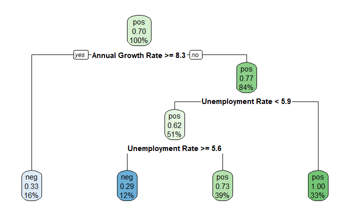

```r
rpart.plot(ct)
```

In the default plot for classification trees each node contains the predicted class chosen as the most common class of the observations in the node, the percentage of the second class within the node and the percentage of observations falling into the node. Considering the root node: the predicted class is `positive` and the distribution of the response in this node is 30% `neg` vs. 70% `pos`. 100% of the observations are in the root node. Take the left node below. The predicted (majority) class in this node is `neg` with a distribution of 67% `neg` and 33% `pos`. 16% of the observations fall into this node.

### Tuning the parameters

#### Pruning

The `rpart()` function also delivers more information on which would be the optimal `cp` to choose for this data set. It performs a cross-validation exercise and the results can be obtained by:

```r
printcp(ct)
```

```
Classification tree:
rpart(formula = DJ_Change_factor ~ ., data = data1[, c(6, 8,
    10, 12)], model = TRUE)

Variables actually used in tree construction:
[1] Annual Growth Rate Unemployment Rate

Root node error: 17/57 = 0.29825

n= 57

        CP nsplit rel error xerror    xstd
1 0.176471      0   1.00000 1.0000 0.20317
2 0.088235      1   0.82353 1.1176 0.20935
3 0.010000      3   0.64706 1.2353 0.21423
```

A graph which shows us how the relative error computed through cross-validation changes for the different values of `cp`:

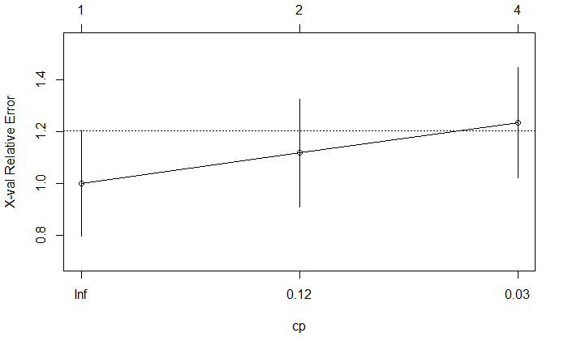

```r
plotcp(ct)
```

```r
ct_pruned <- prune(ct, cp = 0.12)
```

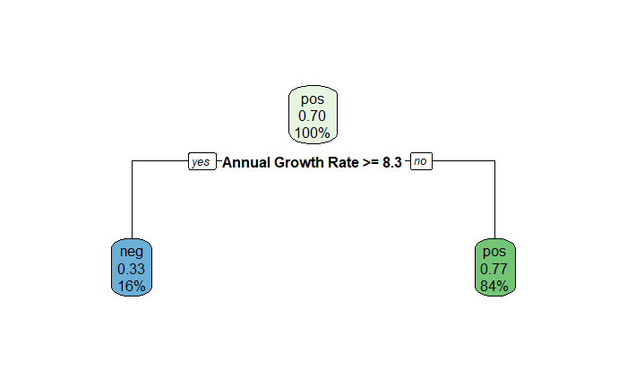

```r
rpart.plot(ct_pruned)
```

The model seems to be pruned to much. So the tree which is not pruned seems like a better choice.

#### Summary

The summary of an `rpart` object returns a long output containing information regarding the fitted tree.

```r
summary(ct)
```

```
Call:
rpart(formula = DJ_Change_factor ~ ., data = data1[, c(6, 8,
    10, 12)], model = TRUE)
  n= 57

          CP nsplit rel error   xerror      xstd
1 0.17647059      0 1.0000000 1.000000 0.2031740
2 0.08823529      1 0.8235294 1.117647 0.2093545
3 0.01000000      3 0.6470588 1.235294 0.2142272

Variable importance
 Unemployment Rate Annual Growth Rate     Inflation Rate
                54                 33                 13

Node number 1: 57 observations,    complexity param=0.1764706
  predicted class=pos  expected loss=0.2982456  P(node) =1
    class counts:    17    40
   probabilities: 0.298 0.702
  left son=2 (9 obs) right son=3 (48 obs)
  Primary splits:
      Annual Growth Rate < 8.31  to the right, improve=2.901316, (0 missing)
      Inflation Rate     < 4.295 to the right, improve=2.250125, (0 missing)
      Unemployment Rate  < 5.825 to the left,  improve=1.702149, (0 missing)
  Surrogate splits:
      Inflation Rate < 6.155 to the right, agree=0.877, adj=0.222, (0 split)

Node number 2: 9 observations
  predicted class=neg  expected loss=0.3333333  P(node) =0.1578947
    class counts:     6     3
   probabilities: 0.667 0.333

Node number 3: 48 observations,    complexity param=0.08823529
  predicted class=pos  expected loss=0.2291667  P(node) =0.8421053
    class counts:    11    37
   probabilities: 0.229 0.771
  left son=6 (29 obs) right son=7 (19 obs)
  Primary splits:
      Unemployment Rate  < 5.875 to the left,  improve=3.3031610, (0 missing)
      Inflation Rate     < 3.305 to the right, improve=0.8065307, (0 missing)
      Annual Growth Rate < 3.245 to the left,  improve=0.7372807, (0 missing)
```

[output cut: 15 more lines]

```

Node number 7: 19 observations
  predicted class=pos  expected loss=0  P(node) =0.3333333
    class counts:     0    19
   probabilities: 0.000 1.000

Node number 12: 7 observations
  predicted class=neg  expected loss=0.2857143  P(node) =0.122807
    class counts:     5     2
   probabilities: 0.714 0.286

Node number 13: 22 observations
  predicted class=pos  expected loss=0.2727273  P(node) =0.3859649
    class counts:     6    16
   probabilities: 0.273 0.727
```

The Classification tree delivers the `Annual Growth Rate` and `Unemployment Rate` as best splitting attributes to assign a class of the DJ_Change_factor to unseen data.

As a conclusion, after running a linear regression we wanted to proof our findings and run a logistic regression and a classification tree. We got two possible models in the end.

# Data 2

```r
data2 <- read.csv(url("https://cdn.discordapp.com/attachments/693802417745166381/699890655765332069/daily_DJ_Gold.csv"), sep = ";", header = TRUE)
```

```r
head(data2)
```

|  | Datum | DJ | DJ.Change | Gold | Gold.Change |
| --- | --- | --- | --- | --- | --- |
| 1 | 27.03.2020 | 21636.78 | 0.00 | 1620.15 | 0.00 |
| 2 | 26.03.2020 | 22552.17 | 4.23 | 1632.50 | 0.76 |
| 3 | 25.03.2020 | 21200.55 | -5.99 | 1615.51 | -1.04 |
| 4 | 24.03.2020 | 20704.91 | -2.34 | 1630.29 | 0.91 |
| 5 | 23.03.2020 | 18591.93 | -10.21 | 1565.05 | -4.00 |
| 6 | 20.03.2020 | 19173.98 | 3.13 | 1497.42 | -4.32 |

```r
summary(data2)
```

```
        Datum            DJ          DJ.Change               Gold         Gold.Change
 01.02.2001:   1   Min.   : 6547   Min.   :-22.080000   Min.   : 255.9   Min.   :-10.99000
 01.02.2002:   1   1st Qu.:10378   1st Qu.: -0.560000   1st Qu.: 422.1   1st Qu.: -0.60000
 01.02.2005:   1   Median :11812   Median : -0.050000   Median : 975.1   Median : -0.02000
 01.02.2006:   1   Mean   :13727   Mean   : -0.008114   Mean   : 928.5   Mean   : -0.02969
 01.02.2007:   1   3rd Qu.:16359   3rd Qu.:  0.480000   3rd Qu.:1305.6   3rd Qu.:  0.49000
 01.02.2008:   1   Max.   :29551   Max.   : 14.850000   Max.   :1896.1   Max.   : 11.06000
 (Other)   :4749
```

Changing the naming scheme of the columns

```r
colnames(data2) <- c("Date", "DJ", "DJ.Change", "Gold", "Gold.Change")
```

Extracting Date of dataset 2 and adding it into the dataset.

```r
data2$Date <- as.Date(gsub("\\.", "\\/", data2$Date),format = '%d/%m/%Y')
```

```r
head(data2)
```

|  | Date | DJ | DJ.Change | Gold | Gold.Change |
| --- | --- | --- | --- | --- | --- |
| 1 | 2020-03-27 | 21636.78 | 0.00 | 1620.15 | 0.00 |
| 2 | 2020-03-26 | 22552.17 | 4.23 | 1632.50 | 0.76 |
| 3 | 2020-03-25 | 21200.55 | -5.99 | 1615.51 | -1.04 |
| 4 | 2020-03-24 | 20704.91 | -2.34 | 1630.29 | 0.91 |
| 5 | 2020-03-23 | 18591.93 | -10.21 | 1565.05 | -4.00 |
| 6 | 2020-03-20 | 19173.98 | 3.13 | 1497.42 | -4.32 |

```r
summary(data2)
```

```
      Date                  DJ          DJ.Change               Gold         Gold.Change
 Min.   :2000-02-28   Min.   : 6547   Min.   :-22.080000   Min.   : 255.9   Min.   :-10.99000
 1st Qu.:2004-11-18   1st Qu.:10378   1st Qu.: -0.560000   1st Qu.: 422.1   1st Qu.: -0.60000
 Median :2009-08-11   Median :11812   Median : -0.050000   Median : 975.1   Median : -0.02000
 Mean   :2009-09-27   Mean   :13727   Mean   : -0.008114   Mean   : 928.5   Mean   : -0.02969
 3rd Qu.:2014-05-01   3rd Qu.:16359   3rd Qu.:  0.480000   3rd Qu.:1305.6   3rd Qu.:  0.49000
 Max.   :2020-03-27   Max.   :29551   Max.   : 14.850000   Max.   :1896.1   Max.   : 11.06000
```

```r
str(data2)
```

```
'data.frame':   4755 obs. of  5 variables:
 $ Date       : Date, format: "2020-03-27" "2020-03-26" "2020-03-25" "2020-03-24" ...
 $ DJ         : num  21637 22552 21201 20705 18592 ...
 $ DJ.Change  : num  0 4.23 -5.99 -2.34 -10.21 ...
 $ Gold       : num  1620 1632 1616 1630 1565 ...
 $ Gold.Change: num  0 0.76 -1.04 0.91 -4 -4.32 -1.91 0.95 3.62 -1.96 ...
```

###Visualization of Dow Jones Prices over the Years

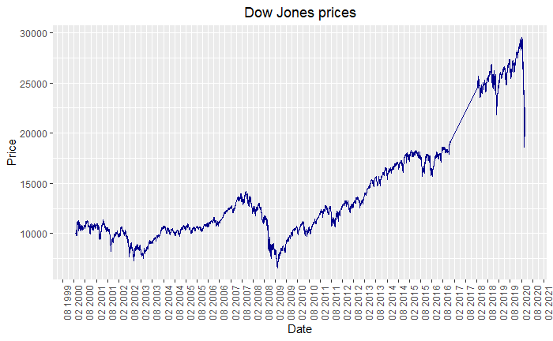

```r
ggplot(data2, aes(x= Date,y = DJ)) + geom_line(color = "darkblue") + ggtitle("Dow Jones prices") + xlab("Date") + ylab("Price") + theme(plot.title = element_text(hjust = 0.5)) + theme(axis.text.x = element_text(angle = 90, hjust = 1)) +  scale_x_date(date_labels = "%m %Y", date_breaks = "6 months")
```

###Visualization of Gold Prices over the Years

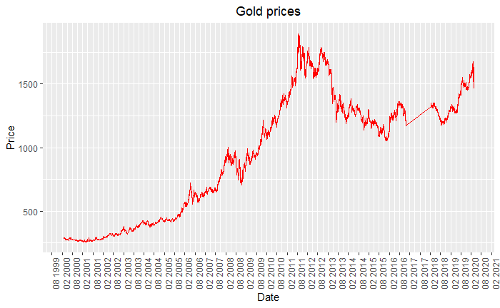

```r
ggplot(data2, aes(x= Date,y = Gold)) + geom_line(color = "red") + ggtitle("Gold prices") + xlab("Date") + ylab("Price") + theme(plot.title = element_text(hjust = 0.5)) + theme(axis.text.x = element_text(angle = 90, hjust = 1)) +  scale_x_date(date_labels = "%m %Y", date_breaks = "6 months")
```

###Visualization of both prices scaled over the Years

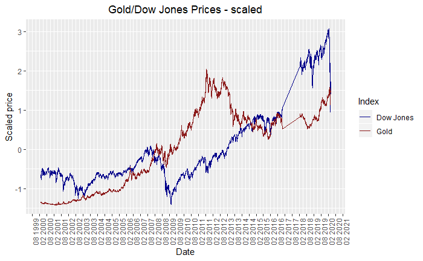

```r
scaled_dj <- scale(data2$DJ)
scaled_gold <- scale(data2$Gold)


ggplot(data2, aes(x = Date)) +
  geom_line(aes(y = scaled_dj, color = "Dow Jones")) + ggtitle("Gold/Dow Jones Prices - scaled") +
  geom_line(aes(y = scaled_gold, color = "Gold")) + xlab("Date") + ylab("Scaled price") +
  theme(plot.title = element_text(hjust = 0.5), panel.border = element_blank()) +
  scale_x_date(date_labels = "%m %Y", date_breaks = "6 months") + theme(axis.text.x = element_text(angle = 90, hjust =1))+ scale_colour_manual("Index", values=c("Dow Jones"="darkblue", "Gold"="firebrick4"))
```

###A better visualization

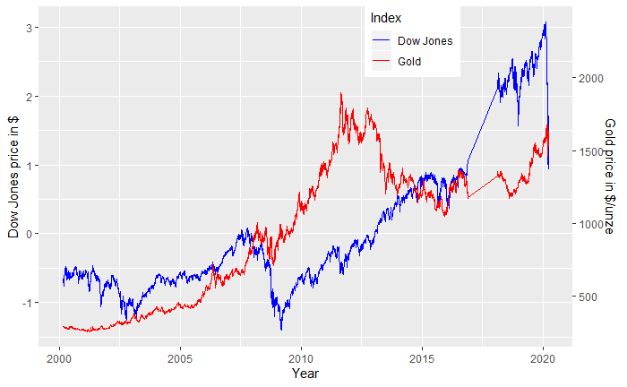

```r
p <- ggplot(data2, aes(x = Date))
  p <- p + geom_line(aes(y = scaled_dj, colour = "Dow Jones"))

  # adding the relative humidity data, transformed to match roughly the range of the temperature
  p <- p + geom_line(aes(y = scaled_gold, colour = "Gold"))

  p <- p + scale_y_continuous(sec.axis =   sec_axis(~.*sd(data2$Gold)+mean(data2$Gold), name = "Gold price in $/unze"))

  # modifying colours and theme options
  p <- p + scale_colour_manual(values = c("blue", "red"))
  p <- p + labs(y = "Dow Jones price in $",
                x = "Year",
                colour = "Index")
  p <- p + theme(legend.position = c(0.7, 0.9))
p
```

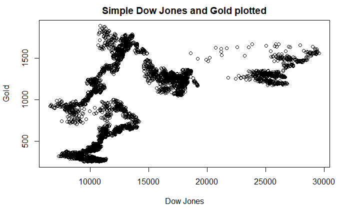

```r
## plot(x, y)
plot(data2$DJ, data2$Gold,
     ylab = "Gold", xlab = "Dow Jones", main = "Simple Dow Jones and Gold plotted")
```

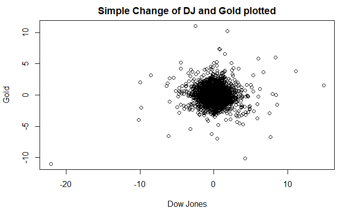

```r
## plot(x, y)
plot(data2$DJ.Change, data2$Gold.Change,
     ylab = "Gold", xlab = "Dow Jones", main = "Simple Change of DJ and Gold plotted")
```

We use this later on for plotting with factors.

```r
data2$`DJ.Change_factor` <- with(data2, ifelse((data2$`DJ.Change` > 0), 1, 0))
data2$`Gold.Change_factor` <- with(data2, ifelse((data2$`Gold.Change` > 0), 1, 0))
```

0 is a negative change and 1 a positive.

[figure not shown]

```r
plot(DJ.Change ~ Gold.Change,
     col = c(1,2),
     data = data2)
legend("bottomleft", title = "Gold Change", pch = 1,
       col = c(1, 2),
       legend= c("Positive", "Negative"))
```

## Correlation Data 2

stock of Dow Jones and stock of Gold

```r
cor(data2[, c(2,4)])
```

```
           DJ     Gold
DJ   1.000000 0.567707
Gold 0.567707 1.000000
```

## Correlation Data 2

changes of Dow Jones and Gold

```r
cor(data2[, c(3,5)])
```

```
              DJ.Change Gold.Change
DJ.Change   1.000000000 0.005471392
Gold.Change 0.005471392 1.000000000
```

## Simple linear regression Data 2

### Fitting the model Data 2

We fit a simple linear regression Dow Jones ~ Gold using OLS using the lm() function:

```r
fitGold <- lm(DJ ~ Gold, data = data2)
```

The fitted coefficients are:

```r
fitGold
```

```
Call:
lm(formula = DJ ~ Gold, data = data2)

Coefficients:
(Intercept)         Gold
   7995.195        6.173
```

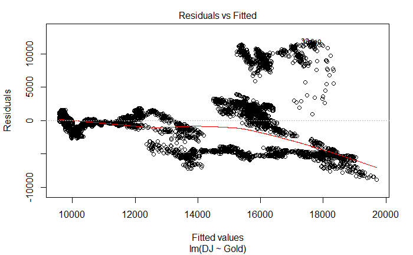

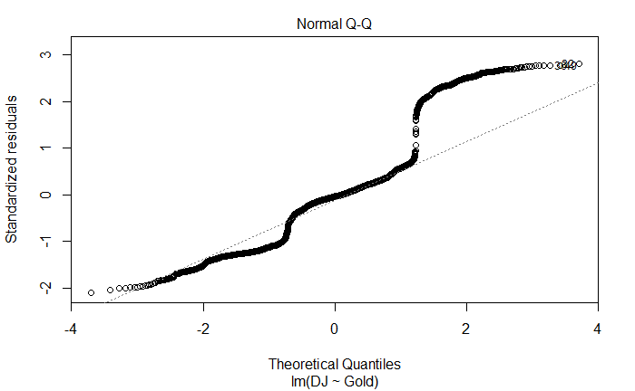

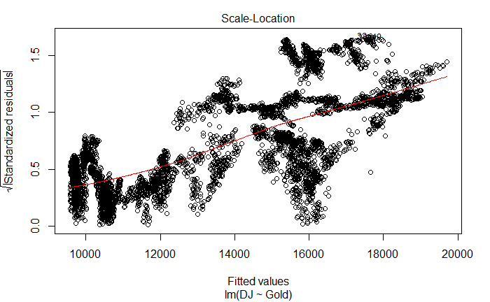

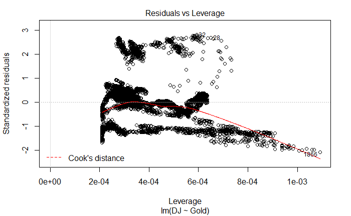

```r
plot(fitGold)
```

The fitted regression line is:
$$\widehat{Dow Jones} = 7995.195 + 6.173 \cdot Gold$$

### K-means Clustering (data 2)

Choosing the first centroids and defining the number of clusters in our model.

```r
# Manually select number of initial values
nstart <- 5
# Manually select optimal number of clusters
clusters <- 4
# k-means Clustering
model.pc <- kmeans(data2[, c(2,4)],
                   centers = clusters,
                   nstart = nstart)
```

We can extract the centroids (the average value of the x and y variables in each cluster) by:

```r
model.pc$centers
```

```
         DJ      Gold
1 17067.458 1246.2049
2 25932.037 1356.6071
3 12706.644 1212.9305
4  9983.216  555.6284
```

Using the clustering to color code the points in the scatterplot:

```r
plot(data2[, c(2,4)], col = model.pc$cluster)
points(model.pc$centers, pch = 3, cex = 2)
```

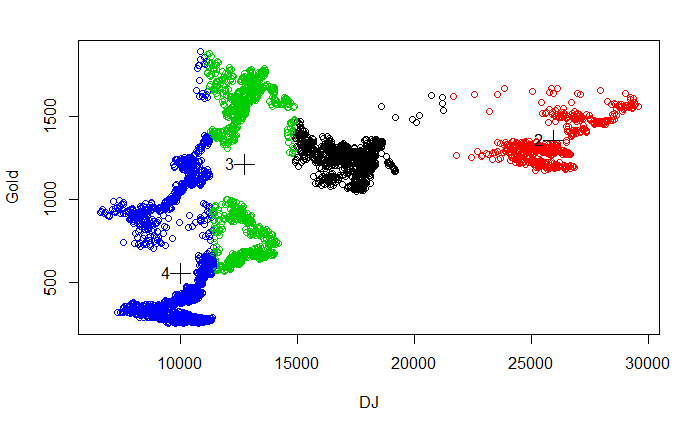

```r
text(model.pc$centers, labels = 1:4, pos = 2)
```

K-Means Clustering obviously didn’t fit so we tried using dbscan.

##DB scan of the dataset 2

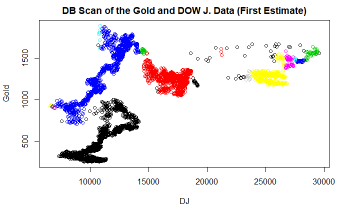

```r
### DBSCAN - minPts = roughly dimension+1
model.dbs <- dbscan::dbscan(data2[, c(2,4)],
                            eps = 100,
                            minPts = 3)
plot(data2[, c(2,4)], col = model.dbs$cluster + 1,
     main = "DB Scan of the Gold and DOW J. Data (First Estimate)")
```

```r
model.dbs
```

```
DBSCAN clustering for 4755 objects.
Parameters: eps = 100, minPts = 3
The clustering contains 16 cluster(s) and 50 noise points.

   0    1    2    3    4    5    6    7    8    9   10   11   12   13   14   15   16
  50    3   41   28    4   60  355    9   16  904   25 1090    7    3    3    4 2153

Available fields: cluster, eps, minPts
```

Now we choose a better Eps.

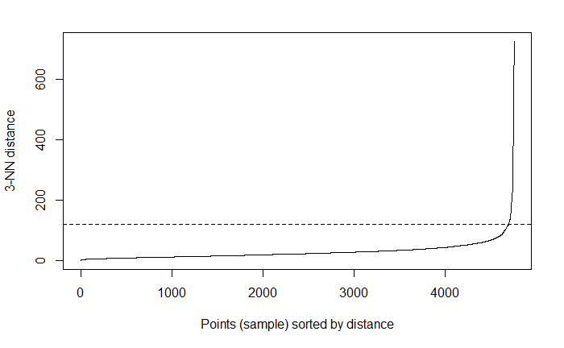

```r
kNNdistplot(data2[, c(2,4)], k = 3)
abline(h = 120, lty = 2)
```

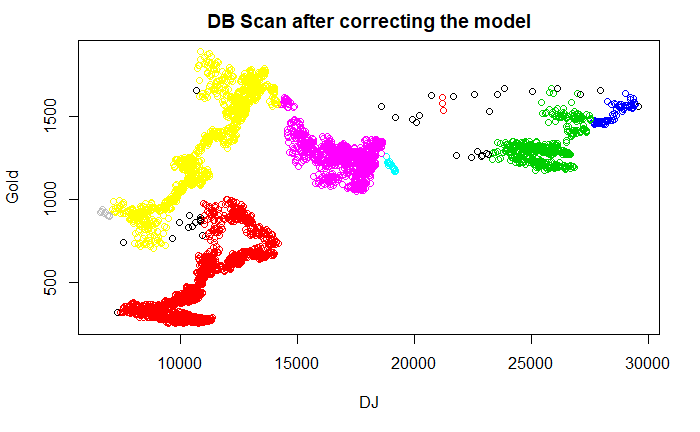

```r
model.dbs <- dbscan::dbscan(data2[, c(2,4)],
                            eps = 120,
                            minPts = 3)
plot(data2[, c(2,4)], col = model.dbs$cluster + 1,
     main = "DB Scan after correcting the model")
```

```r
model.dbs
```

```
DBSCAN clustering for 4755 objects.
Parameters: eps = 120, minPts = 3
The clustering contains 9 cluster(s) and 33 noise points.

   0    1    2    3    4    5    6    7    8    9
  33    3  438   70   16  931 1097    8    5 2154

Available fields: cluster, eps, minPts
```

### Add weekdays to data set (2)

```r
Sys.setlocale("LC_TIME", "en_US")
```

```
OS reports request to set locale to "en_US" cannot be honored
```

```
[1] ""
```

```r
Sys.setlocale("LC_TIME", "English")
```

```
[1] "English_United States.1252"
```

```r
data2$day <- weekdays(data2$Date, abbreviate = FALSE)

data2$day <- ordered(data2$day, levels=c("Monday", "Tuesday", "Wednesday", "Thursday",
"Friday"))
```

```r
str(data2)
```

```
'data.frame':   4755 obs. of  8 variables:
 $ Date              : Date, format: "2020-03-27" "2020-03-26" "2020-03-25" "2020-03-24" ...
 $ DJ                : num  21637 22552 21201 20705 18592 ...
 $ DJ.Change         : num  0 4.23 -5.99 -2.34 -10.21 ...
 $ Gold              : num  1620 1632 1616 1630 1565 ...
 $ Gold.Change       : num  0 0.76 -1.04 0.91 -4 -4.32 -1.91 0.95 3.62 -1.96 ...
 $ DJ.Change_factor  : num  0 1 0 0 0 1 1 0 1 0 ...
 $ Gold.Change_factor: num  0 1 0 1 0 0 0 1 1 0 ...
 $ day               : Ord.factor w/ 5 levels "Monday"<"Tuesday"<..: 5 4 3 2 1 5 4 3 2 1 ...
```

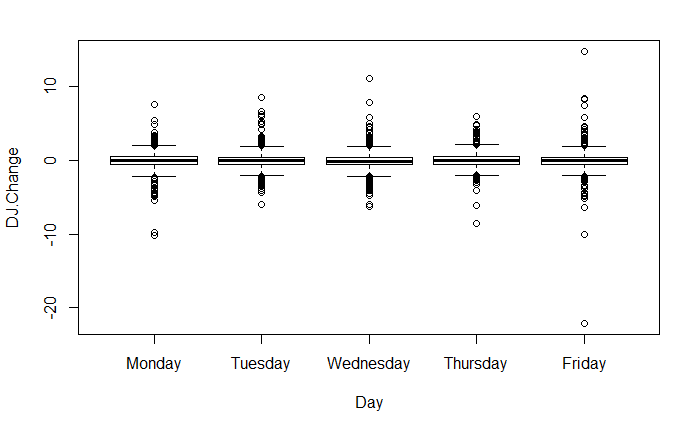

```r
plot(DJ.Change ~ day, data = data2, xlab = "Day")
```

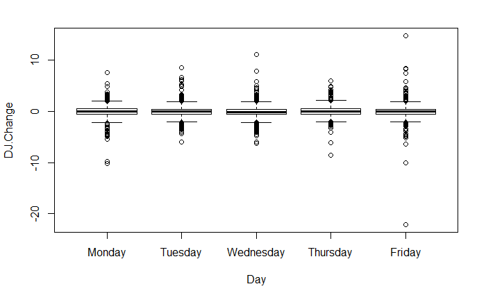

```r
plot(DJ.Change ~ day, data = data2, xlab = "Day")
```

### Add months to data set (2)

```r
data2$month <-months(data2$Date, abbreviate = FALSE)
data2$month <- as.factor(data2$month)

data2$month <- ordered(data2$month, levels=c("January", "February", "March", "April","May", "June", "July", "August", "September","October","November", "December"))
```

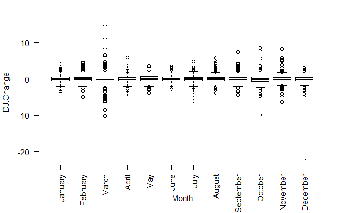

```r
plot(DJ.Change ~ month, data = data2, las = 2, xlab = "Month")
```

### Add years to data set (2)

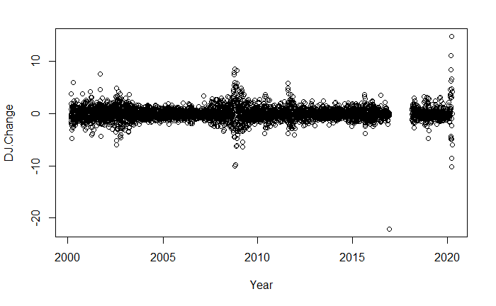

```r
plot(DJ.Change ~ as.Date(data2$Date, "%Y"), data = data2, xlab = "Year")
```

We initially had problems with missing values these are the remenant tries.

```r
#install.packages("naniar")
#library(naniar)
#data2$Gold.Change.. %>%
#  replace_with_na(replace = list(x > 15))
```

```r
#list_na <- colnames(data2)[ apply(data2, 2, anyNA) ]
#list_na
#average_missing <- apply(data2[,colnames(data2) %in% list_na],
#                         2,
#                         mean,
#                         na.rm =  TRUE)
#average_missing
#data2_replace <- data2 %>%
#  mutate(replace_mean_GOLD  = ifelse(is.na(Gold), average_missing[1], Gold),
#         replace_mean_GOLD2 = ifelse(is.na(Gold.Change..), average_missing[2], Gold.Change..))
#
```

## Add weekdays to data set (2)

```r
data2$day <-weekdays(data2$Date, abbreviate = FALSE)
```

```r
str(data2)
```

```
'data.frame':   4755 obs. of  9 variables:
 $ Date              : Date, format: "2020-03-27" "2020-03-26" "2020-03-25" "2020-03-24" ...
 $ DJ                : num  21637 22552 21201 20705 18592 ...
 $ DJ.Change         : num  0 4.23 -5.99 -2.34 -10.21 ...
 $ Gold              : num  1620 1632 1616 1630 1565 ...
 $ Gold.Change       : num  0 0.76 -1.04 0.91 -4 -4.32 -1.91 0.95 3.62 -1.96 ...
 $ DJ.Change_factor  : num  0 1 0 0 0 1 1 0 1 0 ...
 $ Gold.Change_factor: num  0 1 0 1 0 0 0 1 1 0 ...
 $ day               : chr  "Friday" "Thursday" "Wednesday" "Tuesday" ...
 $ month             : Ord.factor w/ 12 levels "January"<"February"<..: 3 3 3 3 3 3 3 3 3 3 ...
```

```r
data2$day <- as.factor(data2$day)
data2$day <- ordered(data2$day, levels=c("Monday", "Tuesday", "Wednesday", "Thursday",
"Friday"))
```

```r
str(data2)
```

```
'data.frame':   4755 obs. of  9 variables:
 $ Date              : Date, format: "2020-03-27" "2020-03-26" "2020-03-25" "2020-03-24" ...
 $ DJ                : num  21637 22552 21201 20705 18592 ...
 $ DJ.Change         : num  0 4.23 -5.99 -2.34 -10.21 ...
 $ Gold              : num  1620 1632 1616 1630 1565 ...
 $ Gold.Change       : num  0 0.76 -1.04 0.91 -4 -4.32 -1.91 0.95 3.62 -1.96 ...
 $ DJ.Change_factor  : num  0 1 0 0 0 1 1 0 1 0 ...
 $ Gold.Change_factor: num  0 1 0 1 0 0 0 1 1 0 ...
 $ day               : Ord.factor w/ 5 levels "Monday"<"Tuesday"<..: 5 4 3 2 1 5 4 3 2 1 ...
 $ month             : Ord.factor w/ 12 levels "January"<"February"<..: 3 3 3 3 3 3 3 3 3 3 ...
```

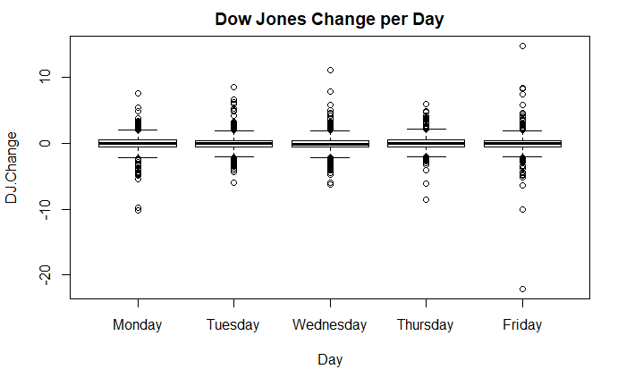

```r
plot(DJ.Change ~ day, data = data2, xlab = "Day", main = "Dow Jones Change per Day")
```

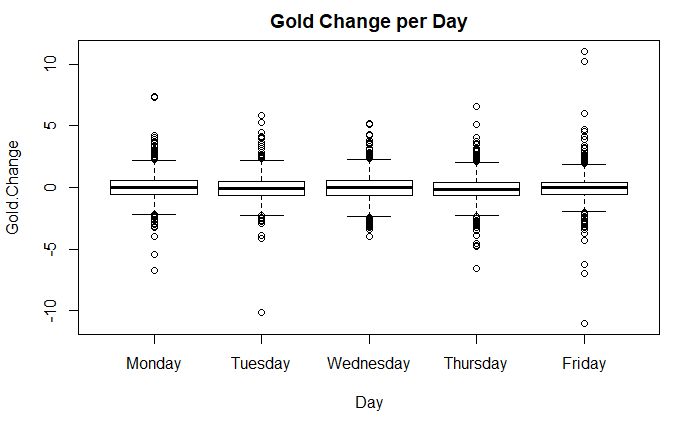

```r
plot(Gold.Change ~ day, data = data2, xlab = "Day", main = "Gold Change per Day")
```

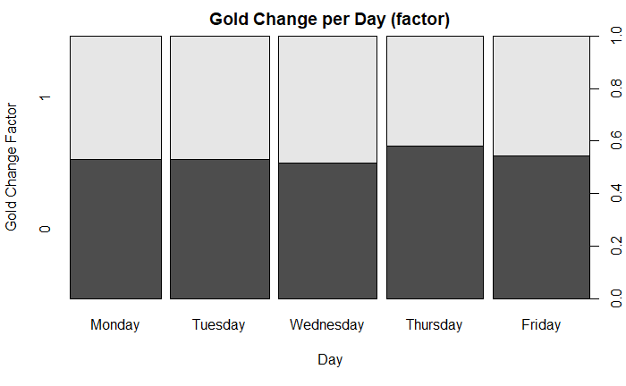

```r
plot(factor(data2$Gold.Change_factor) ~ data2$day, data = data2, xlab = "Day", ylab = "Gold Change Factor", main = "Gold Change per Day (factor)")
```

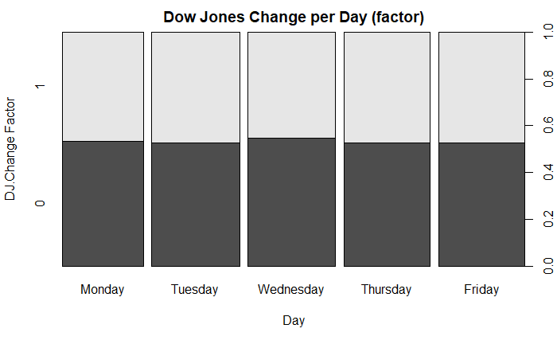

```r
plot(factor(data2$DJ.Change_factor) ~ data2$day, data = data2,xlab = "Day",ylab = "DJ.Change Factor", main = "Dow Jones Change per Day (factor)")
```

We can see that there is no significant difference in changes of DJ and Gold.

## Add months to data set (2)

```r
data2$month <-months(data2$Date, abbreviate = FALSE)
data2$month <- as.factor(data2$month)
data2$month <- ordered(data2$month, levels=c("January", "February", "March", "April","May", "June", "July", "August", "September","October","November", "December"))
```

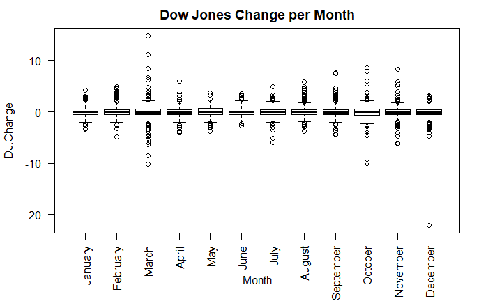

```r
plot(DJ.Change ~ month, data = data2, las = 2, xlab = "Month",main = "Dow Jones Change per Month")
```

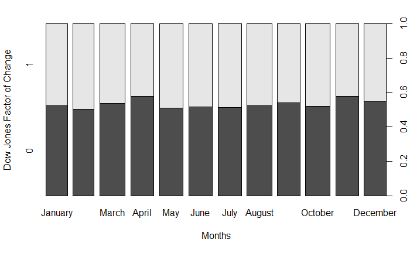

```r
plot(factor(data2$DJ.Change_factor) ~ month, data = data2, las = 2,
     ylab = "Dow Jones Factor of Change", xlab = "Months") #Turning the names of the months like above with las2 did not work for this plot.
```

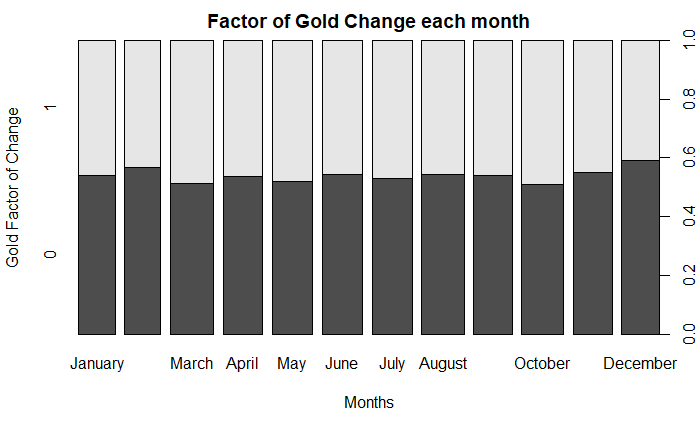

```r
plot(factor(data2$Gold.Change_factor) ~ month, data = data2, las = 2,
     ylab = "Gold Factor of Change", xlab = "Months", main = "Factor of Gold Change each month")
```

## Add years to data set (2)

```r
data2$year <- format(as.Date(data2$Date, format="%d/%m/%Y"),"%Y")
```

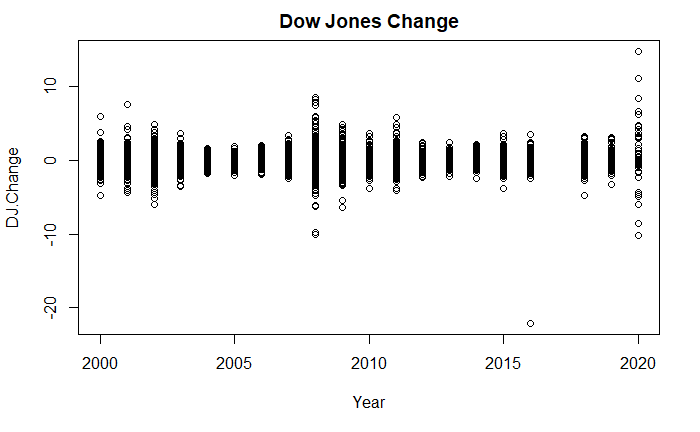

```r
plot(DJ.Change ~ year, data = data2, xlab = "Year", main = "Dow Jones Change")
```

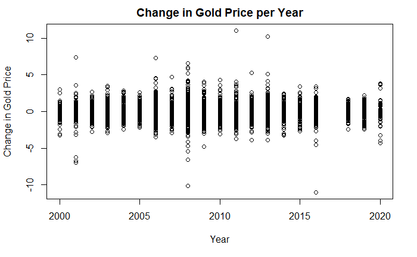

```r
plot(Gold.Change ~ year, data = data2,
     ylab = "Change in Gold Price", xlab = "Year", main = "Change in Gold Price per Year")
```

## Time Series

Two vectors are created using our second data set - one for Dow Jones and one for Gold.

```r
vectorDJ <- data2[,2]
vectorGold <- data2[, 4]
```

##Plotting daily data of Gold and Dow Jones

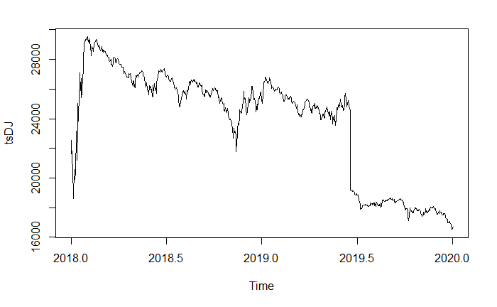

```r
# time series - frequence = 365 means daily
tsDJ <- ts(vectorDJ, start=c(2018, 01, 01), end=c(2020, 02, 28), frequency=365)
tsGold <- ts(vectorGold, start=c(2018, 01, 01), end=c(2020, 02, 28), frequency=365)

# plot series
plot(tsDJ)
```

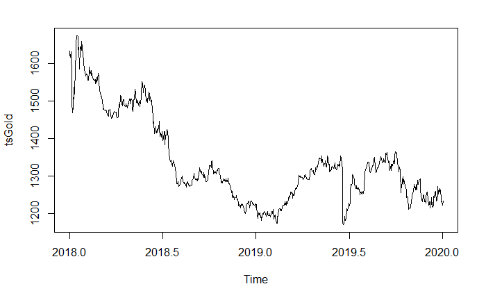

```r
plot(tsGold)
```

To inspect the time series the “stl” function is used. This allows us to see the seasonal components, as well as a trend and a remainder. These might be useful for a prediction.

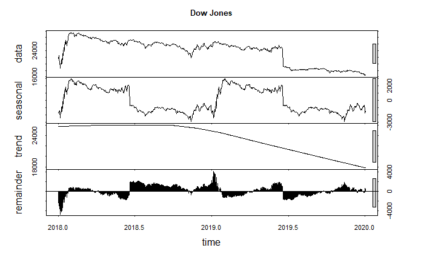

```r
fitDJ <- stl(tsDJ, s.window="period")
fitGold <- stl(tsGold, s.window="period")
plot(fitDJ, main ="Dow Jones")
```

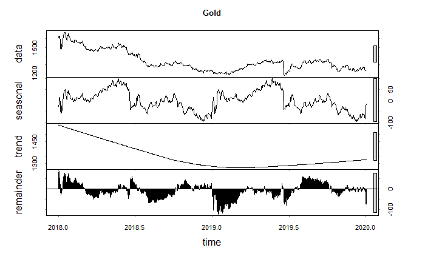

```r
plot(fitGold, main ="Gold")
```

Monthplot is not well usable as there’s too much data because we use a daily frequency.

```r
#monthplot(tsDJ)
```

Here is an attempt of plotting seasonplots. However, they are not that usefull to our research. For that we need the forecast package.

##Looking at seasonal data from Dow Jones and Gold

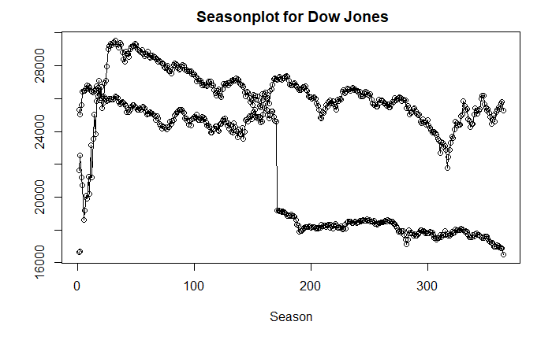

```r
seasonplot(tsDJ, main = " Seasonplot for Dow Jones")
```

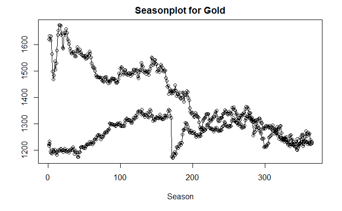

```r
seasonplot(tsGold, main = "Seasonplot for Gold")
```

## Predict future values

### First attempt

Here is our attempt at predicting the future values for our dataset 2.

First, we could use the naive predicting method which would simply be the last value of the data. However, this method is unsufficient.

```r
alpha <- HoltWinters(tsDJ, beta=FALSE, gamma=FALSE)
alpha
```

```
Holt-Winters exponential smoothing without trend and without seasonal component.

Call:
HoltWinters(x = tsDJ, beta = FALSE, gamma = FALSE)

Smoothing parameters:
 alpha: 0.8702254
 beta : FALSE
 gamma: FALSE

Coefficients:
      [,1]
a 16688.55
```

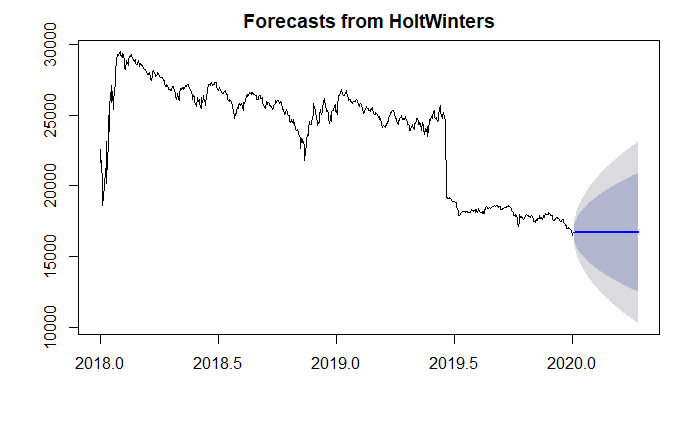

```r
plot(forecast(alpha, 100), type = "l")
```

```r
accuracy(forecast(alpha, 100))
```

```
                    ME    RMSE      MAE         MPE      MAPE       MASE        ACF1
Training set -7.778595 375.157 188.2204 -0.05656045 0.7993189 0.03558641 -0.02228681
```

### Second attempt - using 3rd exponential smoothing

Therefore, the 3rd exponential smoothing is used to deal with seasonality and trends as well.

```r
# triple exponential
fitHWDJ <- HoltWinters(tsDJ)
fitHWGold <- HoltWinters(tsGold)

# predictive accuracy
accuracy(forecast(fitHWDJ))
```

```
                    ME     RMSE      MAE         MPE      MAPE       MASE       ACF1
Training set -12.65622 246.1546 121.9211 -0.05845182 0.6684675 0.02305135 0.07345193
```

```r
accuracy(forecast(fitHWGold))
```

```
                     ME     RMSE      MAE          MPE     MAPE       MASE         ACF1
Training set 0.04512345 11.38135 5.898418 0.0007864245 0.463035 0.04047834 0.0006238483
```

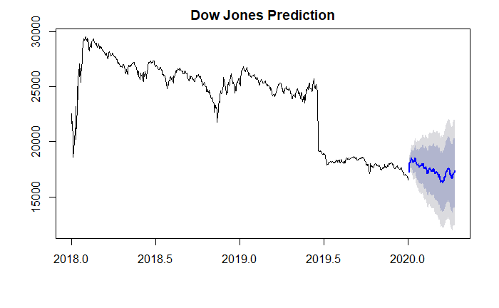

```r
plot(forecast(fitHWDJ, 100), type = "l", main = "Dow Jones Prediction")
```

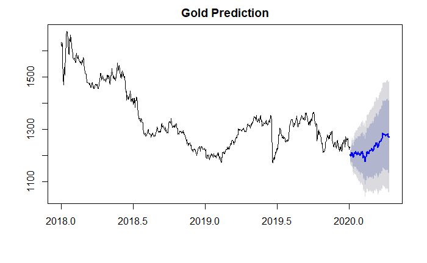

```r
plot(forecast(fitHWGold, 100), type = "l", main = "Gold Prediction")
```

Here we get some decent predictions for our dataset. However, these predictions are simply made from the values of our data. That means they don’t take external factors into account which makes them better than a random guess but I wouldn’t invest all my money using this prediction.